# Cross-validation for hierarchical models

Aki Vehtari

First version 2019-03-11. Last modified 2019-12-04.

# Setup

**Load packages**

```r
library("rprojroot")
root<-has_dirname("modelselection_tutorial")$make_fix_file()
library("loo")
library("rstanarm")
options(mc.cores = parallel::detectCores())
library("ggplot2")
library("bayesplot")
theme_set(bayesplot::theme_default(base_family = "sans"))
```

# 1 Introduction

We demonstrate different cross-validation variants for hierarchical models. [Related video](https://www.youtube.com/watch) discusses the examples used here starting at [22:53](https://www.youtube.com/watch?v=Re-2yVd0Mqk&t=22m53s). For time series specific cross-validation, see Bürkner, Gabry and Vehtari (2019).

# 2 Data

Here we use a simple grouped data. The example data is taken from section 6 of Gelfand *et al.* (1990), and concerns 30 young rats whose weights were measured weekly for five week.

**Load data**

```r
sourceToList = function(file){
  source(file, local = TRUE)
  d = mget(ls())
  d$file = NULL
  d
}
#
rats = sourceToList(root("rats.data.R"))
rats = with(rats, list(
  N = N,
  Npts = length(y),
  rat = rep(1:nrow(y), ncol(y)),
  x = rep(x, each = nrow(y)),
  y = as.numeric(y),
  xbar = xbar
  ))
```

**Create dataframe**

```r
dfrats <- with(rats, data.frame(age=x, age_c=x-22, weight=y, rat=rat))
N <- dim(dfrats)[1]
```

**Plot data**

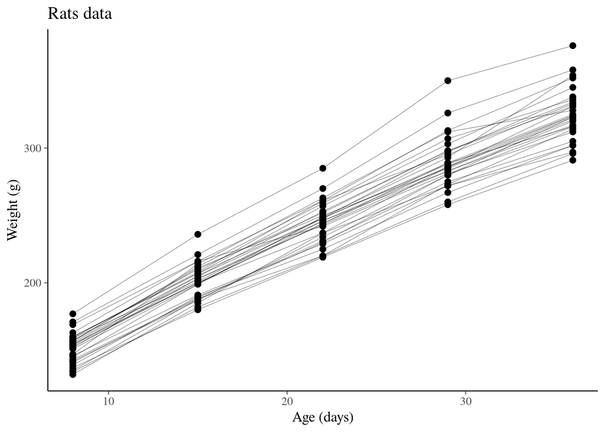

```r
pr <- ggplot(data=dfrats, aes(x=age, y=weight)) +
    geom_line(aes(group=rat), color="black", size=0.1) +
    geom_point(color="black", size=2) +
    labs(x="Age (days)", y="Weight (g)", title="Rats data")
pr
```

Just looking at the data it seems that if the rat growth would be modelled with linear model (up to age 36 days), individual intercept are likely and possibly also individual slopes.

# 3 Models

We compare three models. One with population effect only, another with additional hierarchical intercept term, and third one with hierarchical intercept and slope terms.

**Simple linear model**

```r
fit_1 <- stan_glm(weight ~ age, data=dfrats, refresh=0)
```

**Linear model with hierarchical intercept**

```r
fit_2 <- stan_glmer(weight ~ age + (1 | rat), data=dfrats, refresh=0)
```

**Linear model with hierarchical intercept and slope**

```r
fit_3 <- stan_glmer(weight ~ age + (age | rat), data=dfrats, refresh=0)
```

# 4 Leave-one-out cross-validation

In leave-one-out cross-validation, one observation is left out at time and predicted given all the other observations

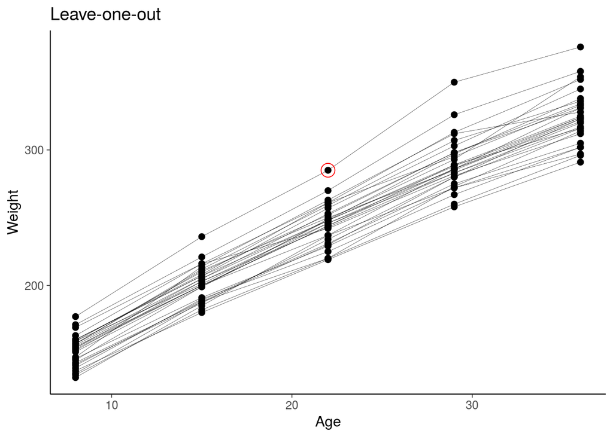

```r
pr1 <- pr +
    geom_point(data=dfrats[69,], color="red", size=5, shape=1) +
    ggtitle('Leave-one-out')
pr1
```

This useful and valid if we are interested in model fit in general, we would use the model to predict random missing data, or if we were comparing different conditional observation models.

`loo` package offers fast Pareto smoothed importance sampling approximation (Vehtari, Gelman and Gabry, 2017,Vehtari+etal:PSIS:2017)

```r
loo_1 <- loo(fit_1)
loo_2 <- loo(fit_2)
loo_3 <- loo(fit_3)
```

We get warnings that PSIS-LOO is failing for the third model. We can check the details

```r
loo_3
```

```
Computed from 4000 by 150 log-likelihood matrix

         Estimate   SE
elpd_loo   -521.1 11.6
p_loo        52.1  6.8
looic      1042.3 23.1
------
Monte Carlo SE of elpd_loo is NA.

Pareto k diagnostic values:
                         Count Pct.    Min. n_eff
(-Inf, 0.5]   (good)     109   72.7%   786
 (0.5, 0.7]   (ok)        29   19.3%   96
   (0.7, 1]   (bad)       10    6.7%   37
   (1, Inf)   (very bad)   2    1.3%   9
See help('pareto-k-diagnostic') for details.
```

As there are only 5 observations per rat, and hierarchical model has 2 rat specific parameters, some of the observations are highly influential and PSIS-LOO is not able to give reliable estimate (if PSIS-LOO fails, WAIC fails, too, but failure of WAIC is more difficult to diagnose (Vehtari, Gelman and Gabry, 2017))

We can run exact LOO-CV for the failing folds.

```r
(loo_3 <- loo(fit_3, k_threshold=0.7))
```

```
Computed from 4000 by 150 log-likelihood matrix

         Estimate   SE
elpd_loo   -522.8 12.2
p_loo        53.7  7.6
looic      1045.6 24.5
------
Monte Carlo SE of elpd_loo is 0.6.

Pareto k diagnostic values:
                         Count Pct.    Min. n_eff
(-Inf, 0.5]   (good)     109   79.0%   786
 (0.5, 0.7]   (ok)        29   21.0%   96
   (0.7, 1]   (bad)        0    0.0%   <NA>
   (1, Inf)   (very bad)   0    0.0%   <NA>

All Pareto k estimates are ok (k < 0.7).
See help('pareto-k-diagnostic') for details.
```

We can now safely do the model comparison

```r
loo_compare(loo_1, loo_2, loo_3)
```

```
       elpd_diff se_diff
model3    0.0       0.0
model2  -23.6       9.3
model1 -109.6      13.3
```

Model 3 is slightly better than model 2. Model 1 is clearly worst. Knowing all the other observations except one, it is beneficial to have individual intercept and slope terms.

# 5 K-fold cross-validation

In K-fold cross-validation the data is divided in K blocks. By different ways to divide the data we can target for different prediction tasks or assess different model parts.

## 5.1 Random K-fold approximation of LOO

Sometimes it is possible that very large number of PSIS-LOO folds fail, and then refitting for all would take long time. We can approximate LOO type cross-validation running K-fold-CV with completely random division of data and then looking at the individual CV predictions.

Helper function `kfold_split_random` can be used to form a random division. We generate random divisions with K=10 and K=30.

```r
cv10rfolds <- kfold_split_random(K=10, N = N)
cv30rfolds <- kfold_split_random(K=30, N = N)
```

Illustrate the first fold with K=30

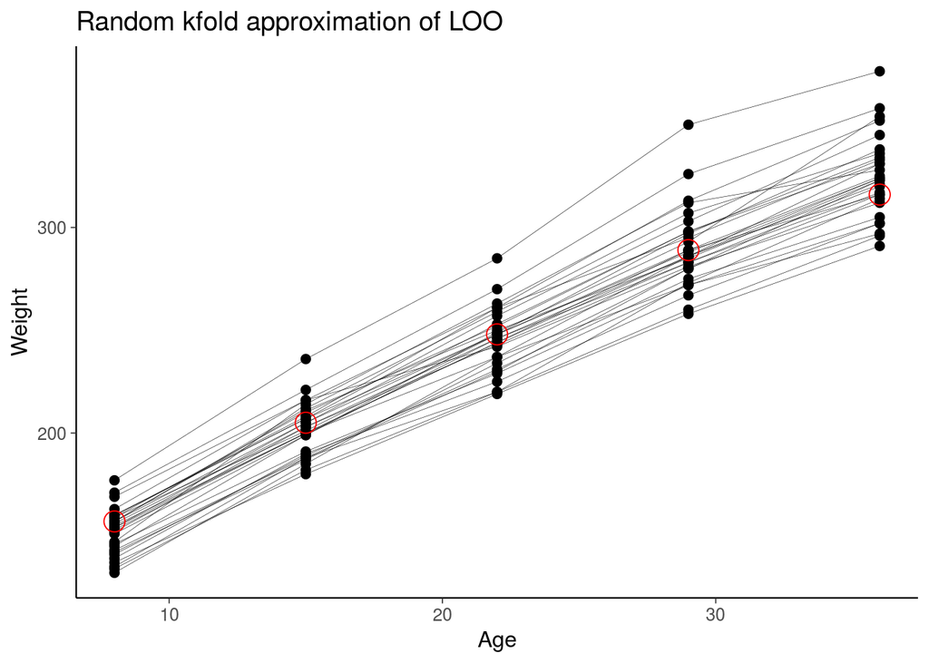

```r
prr <- pr +
    geom_point(data=dfrats[cv30rfolds==1,], color="red", size=5, shape=1) +
    ggtitle('Random kfold approximation of LOO')
prr
```

We use `kfold` function for K-fold cross-validation. (The current release version requires the number of folds (K), but a fixed version can infer it from the folds argument.)

```r
cv10r_1 <- rstanarm::kfold(fit_1, K=10, folds = cv10rfolds)
cv10r_2 <- rstanarm::kfold(fit_2, K=10, folds = cv10rfolds)
cv10r_3 <- rstanarm::kfold(fit_3, K=10, folds = cv10rfolds)
cv30r_1 <- rstanarm::kfold(fit_1, K=30, folds = cv30rfolds)
cv30r_2 <- rstanarm::kfold(fit_2, K=30, folds = cv30rfolds)
cv30r_3 <- rstanarm::kfold(fit_3, K=30, folds = cv30rfolds)
```

Compare models

```r
loo_compare(cv10r_1, cv10r_2, cv10r_3)
```

```
       elpd_diff se_diff
model3    0.0       0.0
model2  -26.2      11.2
model1 -110.1      15.6
```

```r
loo_compare(cv30r_1, cv30r_2, cv30r_3)
```

```
       elpd_diff se_diff
model3    0.0       0.0
model2  -22.4       9.7
model1 -108.0      13.6
```

The results are similar to LOO. In both cases elpd’s are slightly lower than with LOO, and the difference is larger for K=10 and increases with model complexity, which is due to model fitted to less observations than in LOO.

## 5.2 Stratified K-fold approximation of LOO

The random split might just by chance leave out more than one observation from one rat, which would not be good for approximating LOO in case of hierarchical intercept and slope. We can improve by using stratified resampling which ensures that ensuring that relative category frequencies are approximately preserved. In this case it means that from each rat 0 or 1 observation is left out.

Helper function `kfold_split_stratified` can be used to form a stratified division.

```r
cv10sfolds <- kfold_split_stratified(K=10, x = dfrats$rat)
cv30sfolds <- kfold_split_stratified(K=30, x = dfrats$rat)
```

Illustrate the first fold with K=30

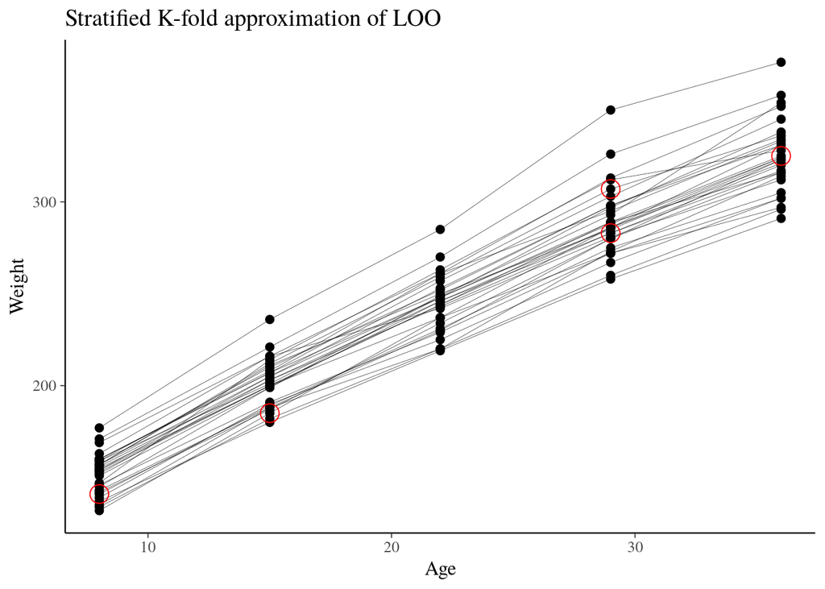

```r
prs <- pr +
    geom_point(data=dfrats[cv30sfolds==1,], color="red", size=5, shape=1) +
    ggtitle('Stratified K-fold approximation of LOO')
prs
```

We use `kfold` function for K-fold cross-validation.

```r
cv10s_1 <- rstanarm::kfold(fit_1, K=10, folds = cv10sfolds)
cv10s_2 <- rstanarm::kfold(fit_2, K=10, folds = cv10sfolds)
cv10s_3 <- rstanarm::kfold(fit_3, K=10, folds = cv10sfolds)
cv30s_1 <- rstanarm::kfold(fit_1, K=30, folds = cv30sfolds)
cv30s_2 <- rstanarm::kfold(fit_2, K=30, folds = cv30sfolds)
cv30s_3 <- rstanarm::kfold(fit_3, K=30, folds = cv30sfolds)
```

Compare models

```r
loo_compare(cv10s_1, cv10s_2, cv10s_3)
```

```
       elpd_diff se_diff
model3    0.0       0.0
model2  -20.9       9.7
model1 -105.9      13.6
```

```r
loo_compare(cv30s_1, cv30s_2, cv30s_3)
```

```
       elpd_diff se_diff
model3    0.0       0.0
model2  -22.6       9.8
model1 -108.3      13.5
```

The results are similar to LOO. In both cases elpd’s are slightly lower than with LOO, and the difference increases with model complexity, which is due to model fitted to less observations than in LOO. For hierarchical models, the results with K=10 and k=30 are closer to each other than in case of complete random division, as stratified division balances the data division.

## 5.3 Grouped K-fold for leave-one-group-out

K-fold cross-validation can also be used for leave-one-group-out cross-validation. In this example one group could be observations from one rat. Leave-one-group-out cross-validation is useful if the future prediction task would be to predict growth curves for new rats, or if we are interested in assessing hierarchical part of the model.

In theory Pareto smoothed importance sampling could be used for leave-one-group-out. In hierarchical models each group has it’s own parameters and the posterior of those parameters tend to change a lot if all observations in that group are removed leading to failure of importance sampling. For certain models quadrature methods could be used to compute integrated (marginalized) importance sampling (Merkle, Furr and Rabe-Hesketh, 2018).

Helper function `kfold_split_grouped` can be used to form a grouped division. With K=30 we have leave-one-rat-out. with K=10 we get faster computation by leaving 3 rats out at time, but the results are likely to be similar with K=30.

```r
cv10gfolds <- kfold_split_grouped(K = 10, x = dfrats$rat)
cv30gfolds <- kfold_split_grouped(K = 30, x = dfrats$rat)
```

Illustrate the first fold with K=30

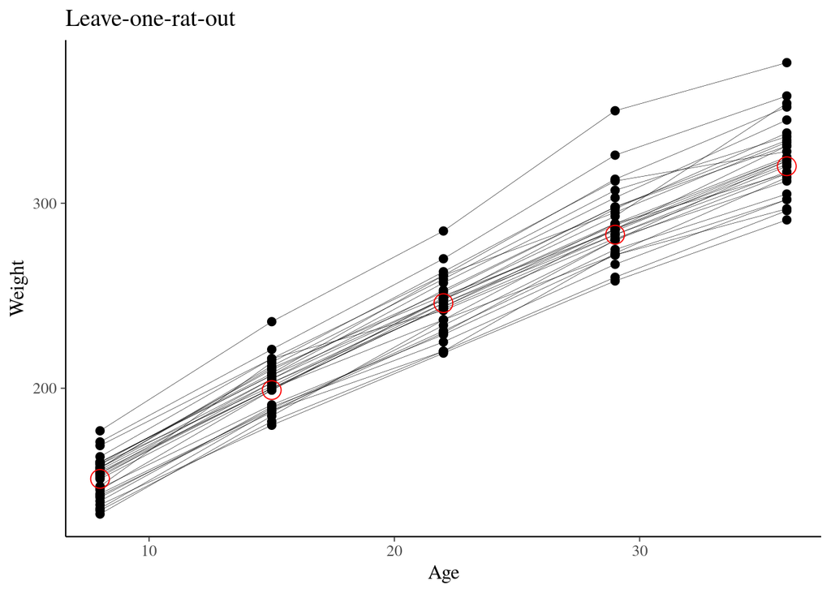

```r
prg <- pr +
    geom_point(data=dfrats[cv30gfolds==1,], color="red", size=5, shape=1) +
    ggtitle('Leave-one-rat-out')
prg
```

We use `kfold` function for K-fold cross-validation.

```r
cv10g_1 <- rstanarm::kfold(fit_1, K=10, folds = cv10gfolds)
cv10g_2 <- rstanarm::kfold(fit_2, K=10, folds = cv10gfolds)
cv10g_3 <- rstanarm::kfold(fit_3, K=10, folds = cv10gfolds)
cv30g_1 <- rstanarm::kfold(fit_1, K=30, folds = cv30gfolds)
cv30g_2 <- rstanarm::kfold(fit_2, K=30, folds = cv30gfolds)
cv30g_3 <- rstanarm::kfold(fit_3, K=30, folds = cv30gfolds)
```

Compare models

```r
loo_compare(cv10g_1, cv10g_2, cv10g_3)
```

```
       elpd_diff se_diff
model3  0.0       0.0
model1 -6.8       4.7
model2 -7.7       5.1
```

```r
loo_compare(cv30g_1, cv30g_2, cv30g_3)
```

```
       elpd_diff se_diff
model3  0.0       0.0
model2 -5.1       3.7
model1 -6.5       4.9
```

In the above model comparison se_diff was computed without taking into account the grouping structure. More accurate computation would first compute group specific elpd.

```r
cvgfix <- function(cv, cvidx) {
    groupwise=numeric();
    K <- length(unique(cvidx))
    for (i in 1:K) { groupwise[i]=sum(cv$pointwise[cvidx==i])}
    cv$pointwise <- cbind(elpd_kfolds=groupwise)
    cv$se_elpd_kfold <- sd(groupwise)*sqrt(K)
    cv$estimates[2] <- cv$se_elpd_kfold
    cv
}
```

note that to sum pointwise elpds for each rat we use 30-fold information also when grouping elpds from 10-fold-CV

```r
cv10gg_1 <- cvgfix(cv10g_1, cv30gfolds)
cv10gg_2 <- cvgfix(cv10g_2, cv30gfolds)
cv10gg_3 <- cvgfix(cv10g_3, cv30gfolds)
cv30gg_1 <- cvgfix(cv30g_1, cv30gfolds)
cv30gg_2 <- cvgfix(cv30g_2, cv30gfolds)
cv30gg_3 <- cvgfix(cv30g_3, cv30gfolds)
```

Now we are comparing 30 groupwise elpds, instead of 150 pointwise elpds.

```r
loo_compare(cv10gg_1, cv10gg_2, cv10gg_3)
```

```
       elpd_diff se_diff
model3  0.0       0.0
model1 -6.8       4.5
model2 -7.7       4.9
```

```r
loo_compare(cv30gg_1, cv30gg_2, cv30gg_3)
```

```
       elpd_diff se_diff
model3  0.0       0.0
model2 -5.1       2.8
model1 -6.5       5.0
```

## 5.4 Grouped K-fold for prediction given initial weight

We can modify cross-validation to different prediction tasks. If in the future we would like to predict growth curves after we have measured the birth weight, we could leave one rat out except for the first observation.

We can sue `kfold_split_grouped` and then form manually an extra group for the initial weight. We now compute results only with K=10.

```r
cv10xfolds <- kfold_split_grouped(K = 10, x = dfrats$rat)
cv10xfolds[dfrats$age==8] <- 11
```

Although we compute only with K=10, we need this to group rat specific predictions before comparison

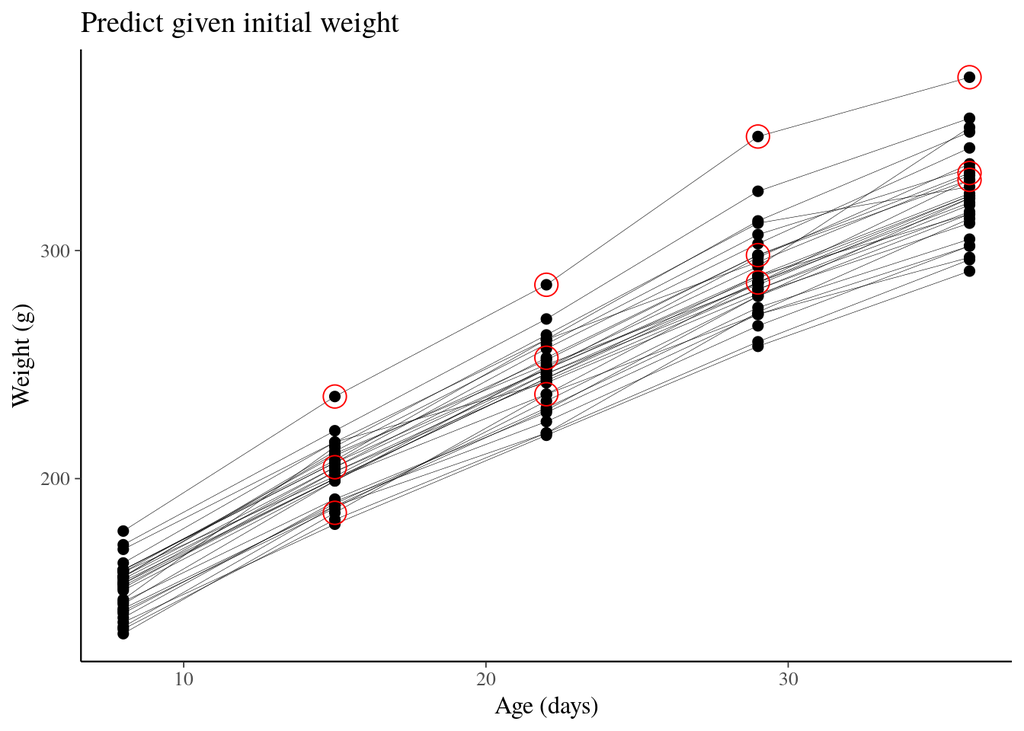

```r
cv30xfolds <- kfold_split_grouped(K = 30, x = dfrats$rat)
cv30xfolds[dfrats$age==8] <- 31
prx <- pr +
    geom_point(data=dfrats[cv10xfolds==1,], color="red", size=5, shape=1) +
    ggtitle('Predict given initial weight')
prx
```

We use `kfold` function for K-fold cross-validation.

```r
cv10x_1 <- rstanarm::kfold(fit_1, K=10, folds = cv10xfolds)
cv10x_2 <- rstanarm::kfold(fit_2, K=10, folds = cv10xfolds)
cv10x_3 <- rstanarm::kfold(fit_3, K=10, folds = cv10xfolds)
```

Compute groupwise elpds

```r
cvxxfix <- function(cv, cvidx) {
    groupwise=numeric();
    K <- length(unique(cvidx))-1
    for (i in 1:K) { groupwise[i]=sum(cv$pointwise[cvidx==i])}
    cv$pointwise <- cbind(elpd_kfolds=groupwise)
    cv$se_elpd_kfold <- sd(groupwise)*sqrt(K)
    cv$estimates[2] <- cv$se_elpd_kfold
    cv
}
cv10xx_1 <- cvxxfix(cv10x_1, cv30xfolds)
cv10xx_2 <- cvxxfix(cv10x_2, cv30xfolds)
cv10xx_3 <- cvxxfix(cv10x_3, cv30xfolds)
```

Compare models

```r
loo_compare(cv10xx_1, cv10xx_2, cv10xx_3)
```

```
       elpd_diff se_diff
model3   0.0       0.0
model2 -15.5      11.8
model1 -44.5      17.4
```

The results are different compared to LOO and LOGO. The order of the models is the same. Model 1 is clearly worse. Knowing the initial weight, we get quite similar predictive accuracy with common slope or hierarchical slope model.

# 6 Alternative models for the prediction given initial weight

If the prediction given initial weight would be interesting task, we could formulate also in different way, which would also illustrate group specific covariate approach.

**Create dataframe**

```r
dfrats2 <- with(rats, data.frame(age=x[x>8], age_c=x[x>8]-25.5, weight=y[x>8], rat=rat[x>8],
                                 initweight_c = rep(y[x==8],4)-mean(y[x==8])))
```

## 6.1 Models

**Simple linear model**

```r
fit2_1 <- stan_glm(weight ~ initweight_c + age_c, data=dfrats2, refresh=0)
```

**Linear model with hierarchical intercept**

```r
fit2_2 <- stan_glmer(weight ~ initweight_c + age_c + (1 | rat), data=dfrats2, refresh=0)
```

**Linear model with hierarchical intercept and slope**

```r
fit2_3 <- stan_glmer(weight ~ initweight_c + age_c + (age_c | rat), data=dfrats2, refresh=0)
```

## 6.2 Grouped K-fold for prediction given initial weight

Helper function `kfold_split_grouped` can be used to form a grouped division.

```r
cv10g2folds <- kfold_split_grouped(K = 10, x = dfrats2$rat)
cv30g2folds <- kfold_split_grouped(K = 30, x = dfrats2$rat)
```

We use `kfold` function for K-fold cross-validation.

```r
cv10g2_1 <- rstanarm::kfold(fit2_1, K=10, folds = cv10g2folds)
cv10g2_2 <- rstanarm::kfold(fit2_2, K=10, folds = cv10g2folds)
cv10g2_3 <- rstanarm::kfold(fit2_3, K=10, folds = cv10g2folds)
```

Compute groupwise elpds

```r
cv10gg2_1 <- cvgfix(cv10g2_1, cv30g2folds)
cv10gg2_2 <- cvgfix(cv10g2_2, cv30g2folds)
cv10gg2_3 <- cvgfix(cv10g2_3, cv30g2folds)
```

```r
loo_compare(cv10gg2_1, cv10gg2_2, cv10gg2_3)
```

```
       elpd_diff se_diff
model3   0.0       0.0
model2 -15.6       5.9
model1 -16.8       6.2
```

Model 3 is clearly the best. When the model includes the initial weight, the hierarchical intercept term doesn’t improve prediction accuracy, but hierarchical slopes do.

# 7 Conclusion

# References

Bürkner, P.-C., Gabry, J. and Vehtari, A. (2019) ‘Approximate leave-future-out cross-validation for time series models’, *arXiv preprint arXiv:1902.06281*. Available at: https://arxiv.org/abs/1902.06281.

Gelfand, A. E., Hills, S. E., Racine-Poon, A. and Smith, A. F. (1990) ‘Illustration of Bayesian inference in normal data models using Gibbs sampling’, *Journal of the American Statistical Association*, 85(412), pp. 972–985.

Merkle, E. C., Furr, D. and Rabe-Hesketh, S. (2018) ‘Bayesian comparison of latent variable models: Conditional vs marginal likelihoods’, *arXiv preprint arXiv:1802.04452*. Available at: https://arxiv.org/abs/1802.04452.

Vehtari, A., Gelman, A. and Gabry, J. (2017) ‘Practical Bayesian model evaluation using leave-one-out cross-validation and WAIC’, *Statistics and Computing*, 27(5), pp. 1413–1432. doi: 10.1007/s11222-016-9696-4.

# Licenses

- Code © 2019, Aki Vehtari, licensed under BSD-3.
- Text © 2019, Aki Vehtari, licensed under CC-BY-NC 4.0.